# 4.3.1.4 Lab - Internet Traffic Data Linear Regression_rus

[figure not shown]

Скрипин Антон Группа: ФТ-360008

## Линейная регрессия интернет-трафика

### Цели

В этой лабораторной работе вы познакомитесь с концепциями регрессии и прогнозирования, а также с концепцией работы с данными.

**Часть 1: Импорт библиотек **

**Часть 2: Визуализация исторических данных **

**Часть 3. Создание простой линейной регрессионной модели: полином первого порядка **

**Часть 4: Создание модели линейной регрессии: полиномы более высокого порядка **

**Часть 5: Вычисление погрешностей**

**Часть 6: Создание модели нелинейной регрессии: Экспоненциальный рост **

**Часть 7: Сравнение модели**

### История/Cценарий

В этой лабораторной работе вы узнаете, как использовать библиотеки Python для применения моделей регрессии к данным. В частности, вам будут показаны исторические данные о росте глобального интернет-трафика и предложено использовать эти данные для прогнозирования его объема в 2020 году.

### Необходимые ресурсы

- 1 ПК с доступом в Интернет
- Библиотеки Python: `pandas`, `numpy`, `sqlite3`, `matplotlib`, `folium_utils`
- Файлы данных: Internet_traffic_hist.csv, Internet_traffic_proj.csv

## Часть 1: Импорт библиотек

В этой части вы будете устанавливать и импортировать библиотеки, необходимые для завершения этой лабораторной работы.

#### Шаг 1: Установите библиотеку scikit-learn.

Эта установка займет несколько минут.

```python
# Ячейка для кода №1
!pip install scikit-learn
```

```
twisted 18.7.0 requires PyHamcrest>=1.9.0, which is not installed.
You are using pip version 10.0.1, however version 18.1 is available.
```

#### Шаг 2. Импортируйте остальные библиотеки.

- pandas
- numpy
- pyplot (и используйте стиль fivethirtyeight или другой, какой вы предпочитаете)

```python
# Ячейка для кода №2
import pandas as pd
import numpy as np
import matplotlib.pyplot as plt
plt.style.use('fivethirtyeight')
%matplotlib inline
```

`sklearn` является одной из наиболее используемых библиотек Python для машинного обучения. Она реализует самые разнообразные методы и предлагает функциональные возможности для предварительной обработки, перекрестной проверки и т.д. Вы можете найти документацию, учебники и многое другое здесь: http://scikit-learn.org/stable/documentation.html

```python
# Ячейка для кода №3
from sklearn.metrics import r2_score
from scipy.optimize import curve_fit
```

## Часть 2. Визуализация исторических данных

#### Шаг 1: Загрузка исторических данных интернет-трафика.

Загрузите набор данных `internet_traffic_hist.csv`, в `Кадр данных` библиотеки `pandas` и визуализируйте первые несколько строк.

```python
# Ячейка для кода №4
filename = 'internet_traffic_hist.csv'
df_hist =pd.read_csv(filename)
df_hist.head(10)
```

|  | traffic | year |
| --- | --- | --- |
| 0 | 100.000000 | 2005 |
| 1 | 126.933755 | 2006 |
| 2 | 160.303757 | 2007 |
| 3 | 203.390603 | 2008 |
| 4 | 241.292566 | 2009 |
| 5 | 308.791823 | 2010 |
| 6 | 379.980659 | 2011 |
| 7 | 495.840568 | 2012 |
| 8 | 616.207252 | 2013 |
| 9 | 752.103483 | 2014 |

#### Шаг 2: Визуализация объема трафика в Интернете.

Согласно [Прогнозу Cisco VNI](http://www.cisco.com/c/en/us/solutions/collateral/service-provider/visual-networking-index-vni/complete-white-paper-c11-481360.html), потребительский проводной интернет-трафик будет расти на 22% в год с 2015 по 2020 год. Для этой лабораторной работы предполагается, что темпы роста были одинаковыми за период с 2005 по 2015 год. В соответствии с этим предположением объем интернет-трафика за 2005 год имеет значение 100. `Кадр данных` `df_hist` содержит изменения объема проводного интернет-трафика до 2015 года (плюс или минус несколько изменений по годам).

Используя изученные ранее функции библиотеки `matplotlib`, визуализируйте изменение объема трафика с каждым годом.

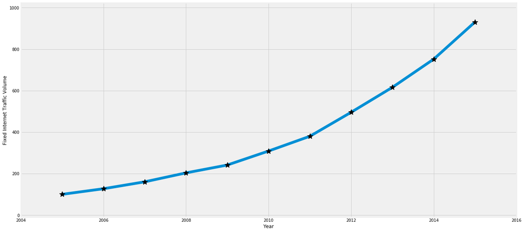

```python
# Ячейка для кода №5
# Создайте фигуру немного большнго размера, используя все доступное пространство
plt.figure(figsize = (20,10))

# График XY зависимости года от траффика
x = df_hist.year
y = df_hist.traffic

# График XY зависимости года от траффика
plt.plot(x, y, label =' ', linewidth = 7)
plt.plot(x, y,'*k', markersize = 14, label = '')

#Увеличьте размеры осей, чтобы сделать график более понятным
plt.axis([x.iloc[0]-1, x.iloc[-1]+1, y.iloc[0]*-0.1,  y.iloc[-1]*1.1])

# Добавьте метки осей
plt.xlabel('Year')
plt.ylabel('Fixed Internet Traffic Volume')

# Увеличьте размер шрифта по умолчанию
plt.rcParams.update({'font.size': 26})
plt.show()
```

## Часть 3: Простая линейная регрессия: полином первого порядка

Для аналитика данных задачу регрессии можно рассматривать в двухэтапном процессе принятия решений:

- Во-первых, **выберите модель регрессии** (или семейство моделей), которая будет использоваться для нахождения математической взаимосвязи между наблюдаемыми переменными,
- Во-вторых, **применение** данной модели к данным, *т.е.* выбор метрики для оценки *качества соответствия* модели и вычисление значений параметров, максимизирующих такую метрику.

Выбор семейства моделей для применения является первым фундаментальным шагом в регрессии.

На первом этапе, *компромисс* находится между более простой моделью, параметры которой легко вычислить, но они могут не удовлетворительно согласовываться с данными, и более сложной, которая может обеспечить более высокое качество применения модели, но требует большего количества вычислений для оценки оптимальных параметров.

Когда выбор семейства моделей сделан, второй шаг также включает в себя *компромисс*: так называемая *дилемма смещения–дисперсии*, которая определяется выбором метрики оценки. Пропуская математические детали, идея состоит в том, что даже для выбранной модели все еще можно точно настроить параметры, чтобы либо повысить качество применения внутри диапазона наблюдаемых данных, либо лучше обобщить их вне этого диапазона.

В остальной части этой лабораторной работы вы увидите примеры того, как выбор, сделанный на первом либо втором шаге, приводит к различным решениям. Цель регрессионного анализа - смоделировать связь между двумя количественными переменными. Общая модель полиномиальной регрессии имеет вид:

$$ y = a_0 + a_1 x + a_2 x ^ 2 +... + a_n x ^ n $$

где `n` порядок степени.

Чтобы понять эту модель регрессии, мы начнем с простой модели линейной регрессии, где переменная n будет равна 1.

Исходя из этого модель становится:

$$ y = a_0 + a_1 x $$

Линейная модель - это модель, параметры которой имеют линейную зависимость от переменных.

Эта модель находится в том же виде, что и линейное уравнение:

$$ y = m x + b $$

где `m` - наклон линии, а `b` - координаты точки пересечения оси у с линией регрессии.

Для семейства моделей регрессии будем учитывать **среднеквадратичную погрешность** (или MSE), как качество метрики соответствия. Идея состоит в том, чтобы наша полиномиальная функция соответствовала нашим данным *как можно ближе*.

#### Шаг 1: Наложение простой модели линейной регрессии на исторические данные Интернета.

В Python функция `polyfit` из библиотеки numpy используется для того, чтобы подогнать модель полиномиальной регрессии любого порядка и поиска параметров, которые минимизируют MSE.

Для первого упражнения с регрессией вы будете использовать семейство **полиномиальных моделей** с порядком 1, в котором переменная интернет-трафика равна $y$, а год - $x$.

```
The slope of line is 79.5271096624497.
The y intercept is -159457.1226583487.
The best fit simple linear regression line is 79.5271096624497x + -159457.1226583487.
```

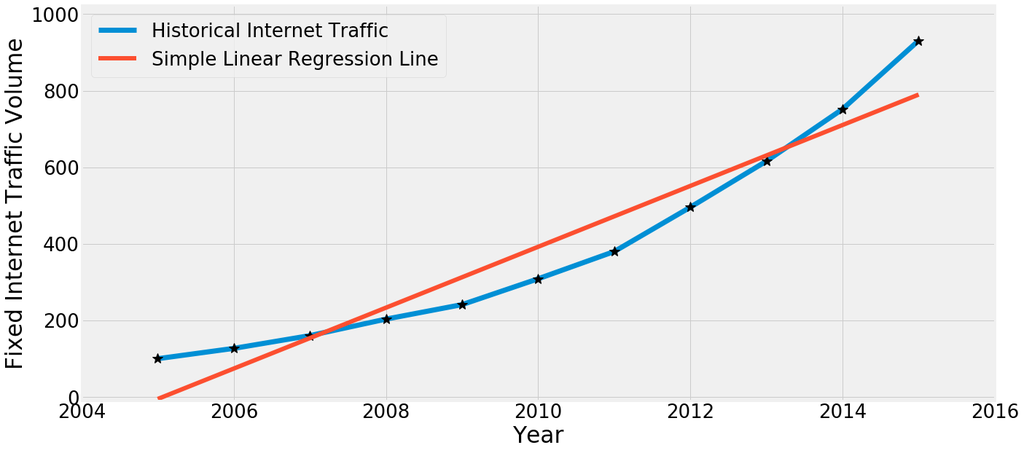

```python
# Ячейка для кода №6
# Создайте фигуру немного большего размера, используя все доступное пространство
plt.figure(figsize = (20,10))

order = 1

# График XY зависимости года от траффика
x = df_hist.year
y = df_hist.traffic

m, b = np.polyfit(x,y,order)

plt.plot(x, y, label = 'Historical Internet Traffic', linewidth = 7)
plt.plot(x, y,'*k', markersize = 15, label ='')
plt.plot(x, m*x + b, '-', label = 'Simple Linear Regression Line', linewidth = 6)

print ('The slope of line is {}.'.format(m))
print ('The y intercept is {}.'.format(b))
print ('The best fit simple linear regression line is {}x + {}.'.format(m,b))


#Увеличьте размеры осей, чтобы сделать график более понятным
plt.axis([x.iloc[0]-1, x.iloc[-1]+1, y.iloc[0]*-0.1, y.iloc[-1]*1.1])

# Добавьте метки осей
plt.xlabel('Year')
plt.ylabel('Fixed Internet Traffic Volume')
plt.legend(loc = 'upper left')


# Увеличьте размер шрифта по умолчанию
plt.rcParams.update({'font.size': 26})
plt.show()
```

## Часть 4: Линейная регрессия: полиномы более высокого порядка

График простой линейной регрессии показывает, что она является не подходящей моделью для прогнозирования интернет-трафика в 2020 году.

Вам необходимо подогнать модель полиномиальной регрессии второго и третьего порядков к историческим данным по трафику Интернета, а также сохранить погрешности и MSE для каждой модели в списке. Это будет использоваться для сравнения моделей регрессии позже в лабораторной работе.

Формула для второго порядка:

$$ y = a_0 + a_1 x + a_2 x ^ 2 $$

Формула для третьего порядка:

$$ y = a_0 + a_1 x + a_2 x ^ 2 + a_3 x ^ 3 $$

Вам необходимо построить полиномиальные модели с возрастающим порядком от 1 до 3 и пронаблюдать соответствие моделей. Полином с порядком 1 уже изображен вами в предыдущей части.

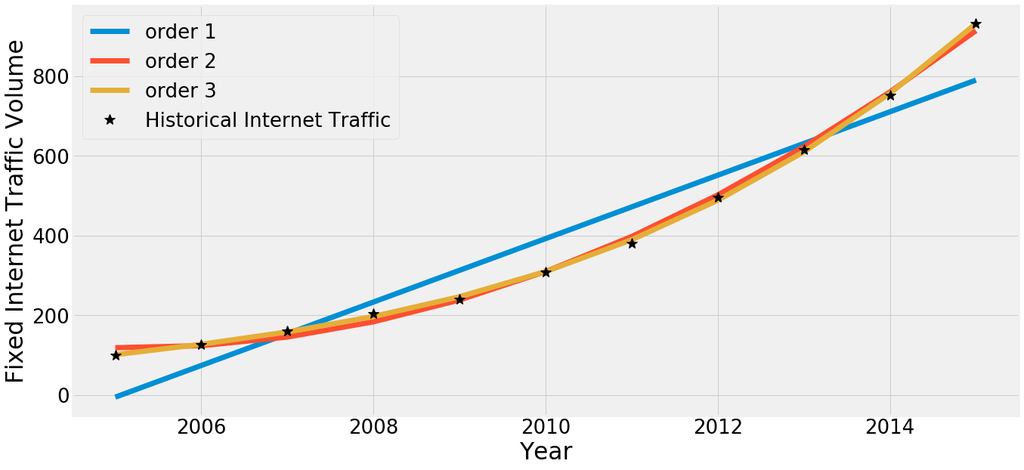

```python
# Ячейка для кода №7
models = []       # для хранения параметров полиномиальной модели (список объектов poly1d)
errors_hist = []  # для хранения абсолютной погрешности для каждой точки (2005-2015) и для каждой модели (список numpy массивов)
mse_hist = []     # для хранения MSE для каждой модели (список numpy чисел с плавающей запятой)

#Примените полиномиальные модели с возрастающим порядком
for order in range(1,4):
    # Примените полиномиальную модель
    p = (np.poly1d(np.polyfit(x, y, order)))
    models.append(p)

plt.figure(figsize = (20,10))

# Визуализируйте применимость полиномиальной модели
for model in models[0:3]:
    plt.plot(x, model(x), label = 'order ' + str(len(model)), linewidth = 7)

plt.plot(x, y, '*k', markersize = 14, label = 'Historical Internet Traffic', linewidth = 7)
plt.legend(loc = 'upper left')

# Добавьте метки осей
plt.xlabel('Year')
plt.ylabel('Fixed Internet Traffic Volume')

plt.show()
```

## Часть 5: Вычисление погрешностей

Сравните погрешности и визуализируйте соответствие для разных моделей регрессии по погрешностям.

Для семейства моделей регрессии будем учитывать **среднеквадратичную погрешность** (или MSE), как качество метрики соответствия. Идея состоит в том, чтобы наша полиномиальная функция соответствовала нашим данным *как можно ближе*.

```python
# Ячейка для кода №8
# Вычислите и сохраните погрешности
models = []       # для хранения параметров полиномиальной модели (список объектов poly1d)
errors_hist = []  # для хранения абсолютной погрешности для каждой точки (2005-2015) и для каждой модели (список numpy массивов)
mse_hist = []     # для хранения MSE для каждой модели (список numpy чисел с плавающей запятой)

#Примените полиномиальные модели с возрастающим порядком
for order in range(1,4):
    # Примените полиномиальную модель
    p = (np.poly1d(np.polyfit(x, y, order)))
    models.append(p)

    e = np.abs(y-p(x))        # абсолютная погрешность
    mse = np.sum(e**2)/len(df_hist) # mse

    errors_hist.append(e)   #Сохраните абсолютные погрешности
    mse_hist.append(mse) # Сохраните mse
```

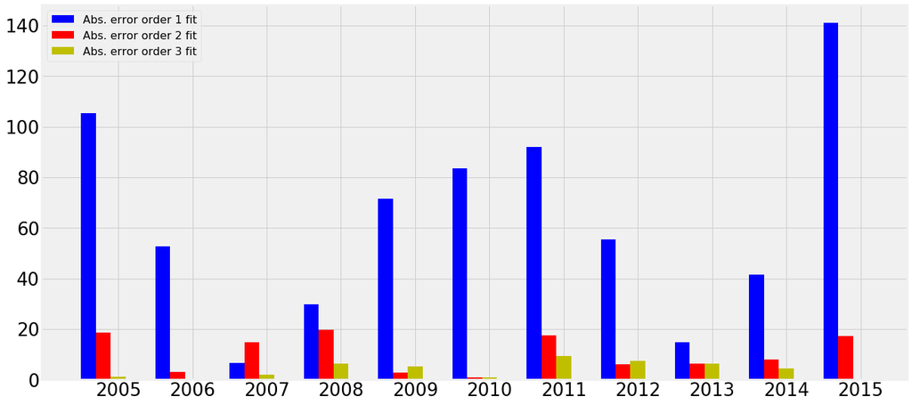

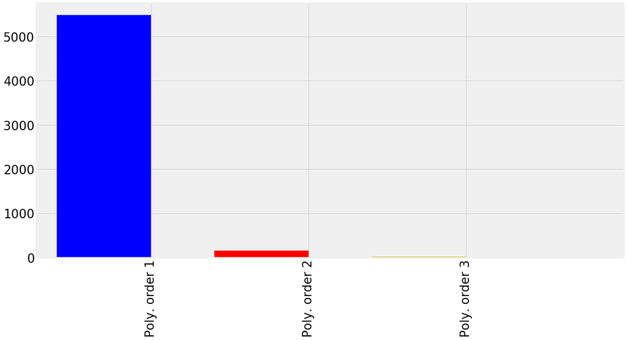

```python
# Ячейка для кода №9
# Визуализируйте погрешность для каждого года

x = df_hist.year
width = 0.2   #размер столбца

fig = plt.figure(figsize=(20,10))
ax = fig.add_subplot(111)

p1 = ax.bar( x, errors_hist[0], width, color = 'b', label = 'Abs. error order 1 fit')
p2 = ax.bar( x + width, errors_hist[1], width, color = 'r', label = 'Abs. error order 2 fit')
p3 = ax.bar( x + 2*width, errors_hist[2], width, color = 'y', label = 'Abs. error order 3 fit')

# "Украсьте" столбцовую диаграмму
ax.set_xticks(x+2*width)
ax.set_xticklabels(x)
plt.legend(loc = 'upper left', fontsize =16)
plt.show()

#Визуализируйте MSE для каждой модели
fig = plt.figure(figsize=(20,10))
ax = fig.add_subplot(111)

x = np.array([0,1,2,3])
width = .6   #размер столбца

p1 = ax.bar( x[0], mse_hist[0], width, color = 'b', label = 'pred. error order 1 fit')
p2 = ax.bar( x[1], mse_hist[1], width, color = 'r', label = 'pred. error order 2 fit')
p3 = ax.bar( x[2], mse_hist[2], width, color = 'y', label = 'pred. error order 3 fit')

ax.set_xticks(x+width/2)
ax.set_xticklabels(['Poly. order 1', 'Poly. order 2', 'Poly. order 3'], rotation=90)
plt.show()
```

Из приведенного выше графика видно, что полином третьего порядка имеет наименьшее количество погрешностей, а также, что разница в количестве погрешностей между полиномами 2-го и 3-го порядка незначительна. Это говорит о том, что полином третьего порядка больше всех подходит для использования в этой лабораторной работе.

Чтобы определить параметры для этого уравнения:

$$ y = a_3 x ^ 3 + a_2 x ^ 2 + a_1 x + a_0 $$

функция Python `polyfit` из библиотеки `numpy` может подогнать модель полиномиальной регрессии любого порядка и найти параметры, которые минимизируют MSE. В ячейке для кода ниже порядок равен 3.

```python
# Ячейка для кода №10
# Порядок полиномиальной функции
order = 3

x = df_hist.year.values      # независимая переменная
y = df_hist.traffic.values   # зависимая переменная

# Примените модель и запишите значения полиномиальных параметров в массив numpy такой, что
# y = p[0]*x**order + p[1]*x*(order-1) ...

p_array = np.polyfit(x,y,order)

print(type(p_array), p_array)

# poly1d - удобный класс, используемый для инкапсуляции “natural” операций на полиномах,
# так чтобы указанные операции могли принимать свою исходную форму в коде

# оберните p_array в объект poly1
p = np.poly1d(p_array)

print(type(p), p)

# используйте объект poly1d для оценки значения полинома в определенной точке
print('The value of the polynomial for x = 2020 is : {} '.format(p(2020)))

# вычислите абсолютную погрешность для каждого значения x и MSE для прогнозируемой полиномиальной модели
e = np.abs(y-p(x))
mse = np.sum(e**2)/len(x)

print('The estimated polynomial parameters are: {}'.format(p))
print('The errors for each value of x, given the estimated polynomial parameters are: \n {}'.format(e))
print('The MSE is :{}'.format(mse))
```

```
<class 'numpy.ndarray'> [ 4.83129470e-01 -2.90500618e+03  5.82252165e+06 -3.89005440e+09]
<class 'numpy.lib.polynomial.poly1d'>         3        2
0.4831 x - 2905 x + 5.823e+06 x - 3.89e+09
The value of the polynomial for x = 2020 is : 2328.578483104706
The estimated polynomial parameters are:         3        2
0.4831 x - 2905 x + 5.823e+06 x - 3.89e+09
The errors for each value of x, given the estimated polynomial parameters are:
 [1.30741405 0.39124263 2.02723313 6.32983589 5.28394069 0.93069372
 9.41691687 7.34010701 6.27730367 4.48133361 0.16290948]
The MSE is :25.172185914969578
```

Исходя из результата применения полинома третьего порядка, выражение принимает вид: $$ y = 0.4831 x ^ 3 - 2905 x ^ 2 + 5.823 * 10^6 x - 3.89 * 10^9 $$

## Часть 6: Нелинейная регрессионная модель: Экспоненциальный рост

В случае данных интернет-трафика мы знаем, что истинная математическая зависимость между трафиком и годом возрастает экспоненциально. Поэтому мы можем использовать её в качестве модели и оценивать наилучшие подходящие параметры $a$ и $r$. Однако экспоненциальный рост является нелинейной функцией, что делает вычисление оптимальных параметров более сложной задачей. Невозможно минимизировать MSE с использованием простого решения в замкнутой форме, поэтому необходим итерационный алгоритм, который возможно, не сможет приблизиться к оптимальному решению. Нелинейная регрессия - это проблема сама по себе.

В отчете VNI указывается ожидаемый годовой темп роста. Поэтому математическую формулу, которая связывает время и объем трафика, можно определить следующим образом:

$$ y = a * (1 + r)^n $$

Формула подчеркивает тот факт, что зависимость между зависимой и независимой переменной включает в себя возведение в степень. По этой причине эта формула называется **экспоненциальным ростом** и может использоваться для описания многих явлений в природе.

Для этой лабораторной работы мы собираемся использовать библиотеку `scipy.optimize` и её функцию `curvefit`. Функция [`curvefit`](https://docs.scipy.org/doc/scipy/reference/generated/scipy.optimize.curve_fit.html) требуется для определения функции кривой, а затем пытается найти наилучшие параметры для указанной функции с использованием нелинейного метода наименьших квадратов.

Детали этой функции и основного алгоритма выходят за рамки этого курса. Однако вы должны знать, что использование модели нелинейной регрессии в общем сложнее с вычислительной точки зрения и что нахождение параметров, которые максимизируют метрику соответствия *не гарантируется*. На самом деле, мы увидим, что поиск хороших параметров может зависеть от наличия хорошей исходной предпосылки.

```python
# Ячейка для кода №11
# Применение нелинейной регрессионной модели

# Сначала определим функцию регрессионной модели, в этом случае мы выберем экспоненту вида y= a*(b^(x))
def my_exp_func(x, a, b):
    return a * (b ** x)

x = np.arange(2016-2005)    # независимой переменной является не сам по себе год, а количество лет с 2005 года
y = df_hist.traffic.values  # зависимая переменная

# используйте curve_fit, чтобы найти вектор экспоненциальных параметров p. cov выражает уверенность
# алгоритма в оцененных параметрах
p, cov = curve_fit(my_exp_func, x, y)
e = np.abs(y - my_exp_func(x, *p))
mse = np.sum(e**2)/len(df_hist)

print('The estimated exponential parameters are: {}'.format(p))
print('The errors for each value of x, given the estimated exponential parameters are: \n {}'.format(e))
print('The MSE is :{}'.format(mse))

models.append(p)

errors_hist.append(e) # Хранит абсолютную погрешность
mse_hist.append(mse)
```

```
The estimated exponential parameters are: [103.37820148   1.24678465]
The errors for each value of x, given the estimated exponential parameters are:
 [ 3.37820148  1.95659906  0.39475809  3.03416216  8.50876833  2.65664482
  8.32850909 11.70265945 12.59154092  0.47531784  7.10276492]
The MSE is :47.23616366678741
```

## Часть 7: Сравнение моделей

Сравните погрешности и визуализируйте соответствие для разных моделей регрессии.

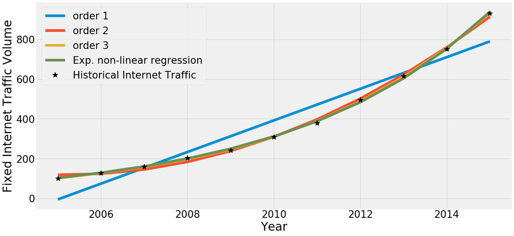

```python
# Ячейка для кода №12
plt.figure(figsize = (20,10))

# Визуализируйте применимость полиномиальной модели
for model in models[0:-1]:

    x = df_hist.year.values
    y = df_hist.traffic.values
    plt.plot(x, model(x), label = 'order ' + str(len(model)), linewidth = 7)

# Визуализируйте применимость полиномиальной модели
x = np.arange(2016-2005)    # независимой переменной является не сам по себе год, а количество лет с 2005 года
plt.plot(df_hist.year.values, my_exp_func(x, *models[-1]), label = 'Exp. non-linear regression', linewidth = 7)

plt.plot(df_hist.year, df_hist.traffic, '*k', markersize = 14, label='Historical Internet Traffic')
plt.legend(loc = 'upper left')

# Добавьте метки осей
plt.xlabel('Year')
plt.ylabel('Fixed Internet Traffic Volume')
plt.show()
```

Для выбранного временного диапазона разница между полиномиальной моделью регрессии 2-го или 3-го порядка и экспоненциальной моделью является незначительной. Давайте посмотрим на фактические погрешности.

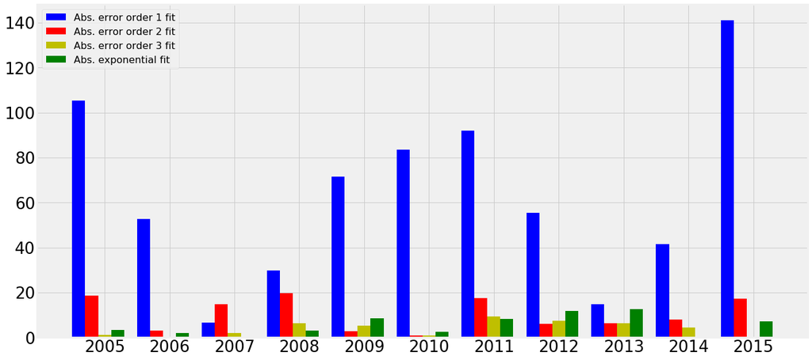

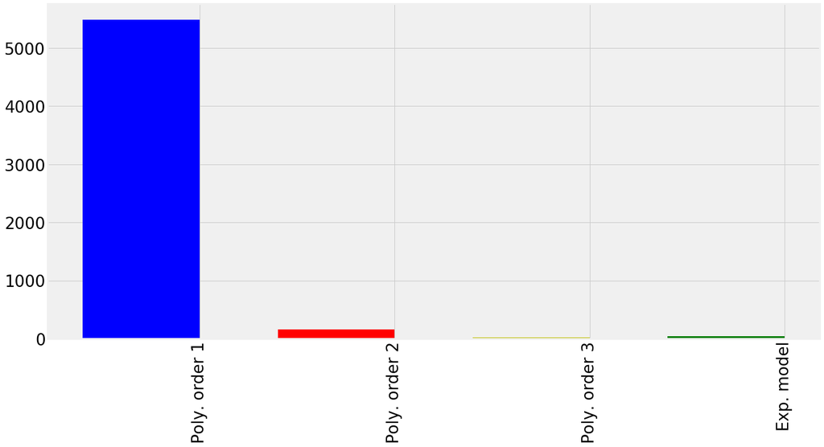

```python
# Ячейка для кода №13
# Визуализируйте погрешность для каждого года

x = df_hist.year
width = 0.2   #размер столбца

fig = plt.figure(figsize=(20,10))
ax = fig.add_subplot(111)

p1 = ax.bar( x, errors_hist[0], width, color = 'b', label = 'Abs. error order 1 fit')
p2 = ax.bar( x + width, errors_hist[1], width, color = 'r', label = 'Abs. error order 2 fit')
p3 = ax.bar( x + 2*width, errors_hist[2], width, color = 'y', label = 'Abs. error order 3 fit')
p4 = ax.bar( x + 3*width, errors_hist[3], width, color = 'g', label = 'Abs. exponential fit')

# "Украсьте" столбцовую диаграмму
ax.set_xticks(x+2*width)
ax.set_xticklabels(x)
plt.legend(loc = 'upper left', fontsize =16)
plt.show()

#Визуализируйте MSE для каждой модели
fig = plt.figure(figsize=(20,10))
ax = fig.add_subplot(111)

x = np.array([0,1,2,3])
width = .6   #размер столбца

p1 = ax.bar( x[0], mse_hist[0], width, color = 'b', label = 'pred. error order 1 fit')
p2 = ax.bar( x[1], mse_hist[1], width, color = 'r', label = 'pred. error order 2 fit')
p3 = ax.bar( x[2], mse_hist[2], width, color = 'y', label = 'pred. error order 3 fit')
p4 = ax.bar( x[3], mse_hist[3], width, color = 'g', label = 'pred. exponential fit')

ax.set_xticks(x+width/2)
ax.set_xticklabels(['Poly. order 1', 'Poly. order 2', 'Poly. order 3', 'Exp. model' ], rotation=90)
plt.show()
```

Из последнего графика кажется, что полином третьего порядка, не являясь *истиной* моделью, лучше подходит для измерения трафика в наблюдаемом диапазоне. Но насколько хорошо эта модель будет обобщаться вне этого диапазона (*например*, если мы хотим использовать её, чтобы сделать **прогнозы** о будущем объеме интернет-трафика)?

## Часть 8: Используйте модель регрессии для прогнозирования будущих значений

В этой части вы рассмотрите прогнозируемые значения для объема фиксированного интернет-трафика. Предполагая одинаковые темпы роста на период 2005-2015 годов, данные генерируются и сохраняются в наборе данных `internet_traffic_proj.csv`. Загрузите его содержимое в `Кадр данных` с именем `df_proj` и визуализируйте первые несколько строк.

#### Шаг 1: Загрузка и визуализация прогнозируемого объема интернет-трафика.

```python
# Ячейка для кода №14
filename = 'internet_traffic_proj.csv'
df_proj = pd.read_csv(filename)
df_proj.head(10)
```

|  | traffic | year |
| --- | --- | --- |
| 0 | 931.200929 | 2015 |
| 1 | 1266.783122 | 2016 |
| 2 | 1427.662376 | 2017 |
| 3 | 1749.671543 | 2018 |
| 4 | 2281.869542 | 2019 |
| 5 | 3000.117699 | 2020 |

#### Шаг 2. Сравните погрешности прогнозирования для линейной и нелинейной модели.

Объедините `df_proj` и `df_hist` `кадры данных`, и визуализируйте, как ведет себя ранее примененная модель регрессии при прогнозировании будущих значений.

```python
# Ячейка для кода №15
df = pd.concat([df_hist, df_proj]).reset_index()
df.drop('index', axis=1, inplace=True)
df = df.drop_duplicates() #Значение 2015 можно найти, как в df_hist, так и в df_proj df
df.head(20)
```

|  | traffic | year |
| --- | --- | --- |
| 0 | 100.000000 | 2005 |
| 1 | 126.933755 | 2006 |
| 2 | 160.303757 | 2007 |
| 3 | 203.390603 | 2008 |
| 4 | 241.292566 | 2009 |
| 5 | 308.791823 | 2010 |
| 6 | 379.980659 | 2011 |
| 7 | 495.840568 | 2012 |
| 8 | 616.207252 | 2013 |
| 9 | 752.103483 | 2014 |
| 10 | 931.200929 | 2015 |
| 12 | 1266.783122 | 2016 |
| 13 | 1427.662376 | 2017 |
| 14 | 1749.671543 | 2018 |
| 15 | 2281.869542 | 2019 |
| 16 | 3000.117699 | 2020 |

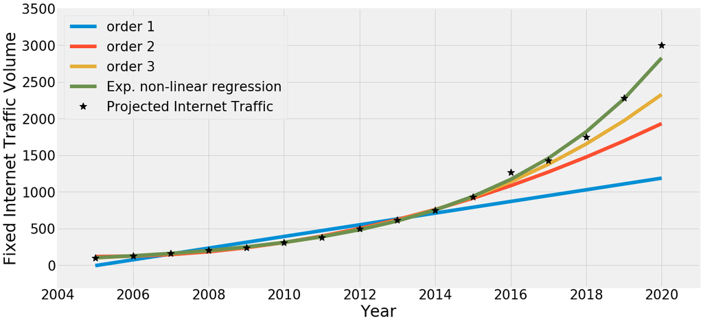

```python
# Ячейка для кода №16
plt.figure(figsize = (20,10))

errors_all = []
mse_all = []

for model in models[0:-1]:

    # Визуализируйте применимость полиномиальной модели
    x = df.year.values
    y = df.traffic.values
    plt.plot(x, model(x), label = 'order ' + str(len(model)), linewidth = 7)

    # погрешности и mse для полиномиальных моделей
    pred_y = model(x)
    e = np.abs(y - pred_y)
    errors_all.append(e)   #Хранит абсолютную погрешность
    mse_all.append(np.sum(e**2)/len(df)) # Хранит mse


# Визуализируйте применимость экспоненциальной модели
x = np.arange(2021-2005)    # независимой переменной является не сам по себе год, а количество лет с 2005 года
pred_y = my_exp_func(x, *models[-1])
plt.plot(df.year.values, pred_y, label = 'Exp. non-linear regression', linewidth = 7)

# погрешности и mse для экспоненциальной модели
e = np.abs(y - pred_y)
errors_all.append(e)   #Хранит абсолютную погрешность
mse_all.append(np.sum(e**2)/len(df)) # Хранит mse

plt.plot(df.year, df.traffic, '*k', markersize = 14, label='Projected Internet Traffic')
plt.legend(loc = 'upper left')

# Добавьте метки осей
plt.xlabel('Year')
plt.ylabel('Fixed Internet Traffic Volume')
plt.axis([2004,2021, -300, 3500])
plt.show()
```

Какой вывод вы можете сделать о полиномиальной модели 3-го порядка и экспоненциальной модели?

Так как рост является экспотенциальным мы не можем точно прогнозировать дальнейший рост с ипользованием модели 3 го порядка, в о отличии от экспотенциальной модели

© 2017 Cisco and/or its affiliates. All rights reserved. This document is Cisco Public.